# Cardiovascular Outcomes in Heart Failure Patients

Principal Investigator: John Kostis  
Co-Investigator: Michail Giakoumis, Georgia Barbayannis  
Statistician: Davit Sargsyan  
Date: Fri Jun 21 23:28:37 2019

# Part I: Data

```r
load("data/case.RData")

# ATTN! FIX THIS!
case <- case[, -1]

# Make age per 10 year
case$decade <- floor(case$AGE/10)

# Load hospital characteristics and merge
# Source: Georgia's Dakota project
dthosp <- fread("data/NJ HOSPITALS_Heart Attack Scores 2017.csv")
dthosp <- unique(dthosp[, c("Hospital Number",
                            "CLAB",
                            "Area",
                            "Teach")])
colnames(dthosp)[1] <- "HOSP"

# Remove hospitals with missing/ambiguous information
dthosp <- dthosp[-c(16, 45, 62, 73), ]

case$HOSP <- as.numeric(as.character(case$HOSP))
case <- merge(case,
              dthosp,
              by = "HOSP",
              all.x = TRUE)

case$CLAB[is.na(case$CLAB)] <- -1
case$CLAB <- factor(case$CLAB,
                    levels = rev((-1):1),
                    labels = c("Cath Lab",
                               "No Cath Lab",
                               "Unknown"))

case$Area[is.na(case$Area)] <- -1
case$Area <- factor(case$Area,
                    levels = c("U",
                               "I",
                               "R",
                               "S",
                               "-1"),
                    labels = c("Urban",
                               "Inner city",
                               "Rural",
                               "Suburb",
                               "Unknown"))

case$Teach[is.na(case$Teach)] <- -1
case$Teach <- factor(case$Teach,
                    levels = rev((-1):1),
                    labels = c("Teaching",
                               "Non-Teaching",
                               "Unknown"))
```

```r
# HF discharges----
t1 <- table(case$DSCYR)
t1 <- data.table(Year = as.integer(names(t1)),
                 Counts = c(t1))
dt.age <- aggregate(case$AGE,
                    by = list(Year = case$DSCYR),
                    FUN = "mean")
dt.age$x <- round(dt.age$x, 1)
names(dt.age)[2] <- "Age at 1st HF"

dt.age$Year <- as.numeric(dt.age$Year)

t1 <- merge(t1,
            dt.age,
            by = "Year")

DT::datatable(t1,
              caption = "Table 1: Number of first HF discharges by year",
              rownames = FALSE,
              class = "cell-border stripe",
              options = list(searching = TRUE,
                             pageLength = nrow(t1)))
```

| Year | Counts | Age at 1st HF |
| --- | --- | --- |
| 1995 | 14197 | 74.1 |
| 1996 | 10475 | 74.3 |
| 1997 | 9329 | 74 |
| 1998 | 8635 | 73.7 |
| 1999 | 7811 | 73.9 |
| 2000 | 7760 | 73.4 |
| 2001 | 7345 | 73.2 |
| 2002 | 7271 | 73 |
| 2003 | 7205 | 73.3 |
| 2004 | 6462 | 73 |

[output cut: 11 more lines]

# Plot of number of new HF patients form 1995 to 2015

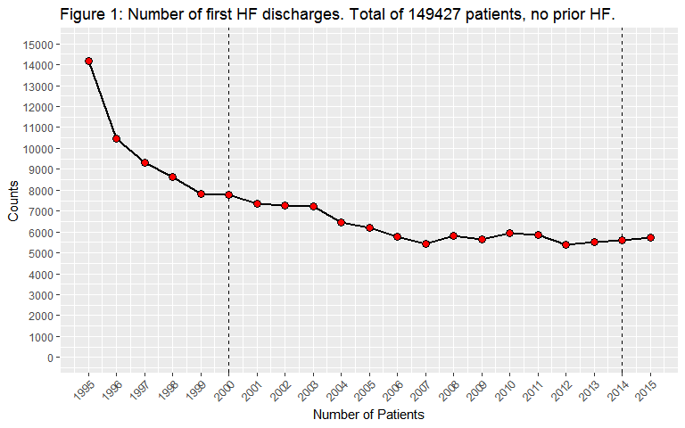

```r
# Plot HF discharges----
p0 <- ggplot(t1,
             aes(x = Year,
                 y = Counts)) +
  geom_line(size = 1) +
  geom_vline(xintercept = c(2000, 2014),
             linetype = "dashed") +
  geom_point(size = 3,
             shape = 21,
             fill = "red") +
  scale_x_continuous("Number of Patients",
                     breaks = 1995:2015,
                     limits = c(1995, 2015)) +
  scale_y_continuous(breaks = seq(0, 15000, 1000),
                     limits = c(0, 15000)) +
  ggtitle(paste("Figure 1: Number of first HF discharges. Total of",
                nrow(case),
                "patients, no prior HF.")) +
  theme(axis.text.x = element_text(angle = 45,
                                   hjust = 1),
        plot.title = element_text(hjust = 0))
p0
```

**NOTE**: the higher number of patients in the early years could be due to censored records containing prior HF; hence, more patients remained. Also, we needed at least one year follow-up for all patients; hence, we restricted records to 2000-2014 interval.

# Plot of number of new HF patients form 2000 to 2014

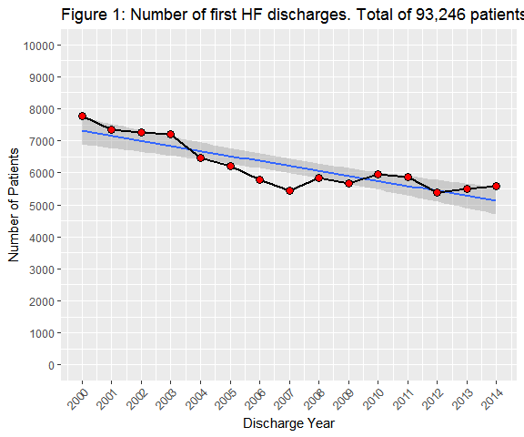

```r
t2 <- t1[Year > 1999 &
                  Year < 2015, ]
# Plot HF discharges----
p0 <- ggplot(t2,
             aes(x = Year,
                 y = Counts)) +
  geom_smooth(method = "lm") +
  geom_line(size = 1) +
  geom_point(size = 3,
             shape = 21,
             fill = "red") +
  scale_x_continuous("Discharge Year",
                     breaks = 2000:2014,
                     limits = c(2000, 2014)) +
  scale_y_continuous("Number of Patients",
                     breaks = seq(0, 10000, 1000),
                     limits = c(0, 10000)) +
  ggtitle(paste("Figure 1: Number of first HF discharges. Total of",
                format(nrow(case[DSCYR > 1999 &
                                   DSCYR < 2015]),
                       big.mark = ","),
                "patients, no prior HF.")) +
  theme(axis.text.x = element_text(angle = 45,
                                   hjust = 1),
        plot.title = element_text(hjust = 0))

# Save for publication
pp0 <- p0 +
  ggtitle("") +
  theme(legend.position = "none")
tiff(filename = "tmp/fig1.tiff",
     height = 5,
     width = 6,
     units = "in",
     res = 600,
     compression = "lzw+p")
print(pp0)
graphics.off()

print(p0)
```

```r
# Linear trend
t2$years <- t2$Year - 2000
m1 <- lm(Counts ~ years,
         data = t2)
summary(m1)
```

```
Call:
lm(formula = Counts ~ years, data = t2)

Residuals:
   Min     1Q Median     3Q    Max
-772.4 -235.4  191.5  278.8  461.1

Coefficients:
            Estimate Std. Error t value Pr(>|t|)
(Intercept)  7305.87     195.94  37.287 1.33e-14 ***
years        -155.64      23.82  -6.534 1.90e-05 ***
---
Signif. codes:  0 ‘***’ 0.001 ‘**’ 0.01 ‘*’ 0.05 ‘.’ 0.1 ‘ ’ 1

Residual standard error: 398.6 on 13 degrees of freedom
Multiple R-squared:  0.7666,    Adjusted R-squared:  0.7486
F-statistic:  42.7 on 1 and 13 DF,  p-value: 1.9e-05
```

```r
case <- case[DSCYR > 1999 & DSCYR < 2015, ]

# Pubication/Table1: Demographics----
# summary(case)
table1 <- data.table(Description = c("Mean Age at First AMI Admission +/- S.D",
                                     "Female (%)",
                                     "Race (%)",
                                     "* White",
                                     "* Black",
                                     "* Other",
                                     "Ethnicity (%)",
                                     "* Hispanic",
                                     "* Non-hispanic",
                                     "* Unknown",
                                     "Insurance(%)",
                                     "* Commercial",
                                     "* Medicare",
                                     "* Medicaid/Self-Pay/Other",
                                     "Admission Hospital Type (%)",
                                     "* Teaching",
                                     "* Non-Teaching",
                                     "* Unknown",
                                     "Admission to Hospital Area (%)",
                                     "* Urban",
                                     "* Inner city",
                                     "* Rural",
                                     "* Suburb",
                                     "* Unknown",
                                     "Admission Hospital Cath Lab",
                                     "* Cath Lab",
                                     "* No Cath Lab",
                                     "* Unknown",
                                     "Number of HF Patients"),
                     `Number of Patients` = c(paste(round(mean(case$AGE), 1),
                                                    "+/-",
                                                    round(sd(case$AGE), 1),
                                                    sep = ""),
                                              format(sum(case$SEX == "F"),
                                                     big.mark = ","),
                                              "",
                                              format(sum(case$RACE == "White"),
                                                     big.mark = ","),
                                              format(sum(case$RACE == "Black"),
                                                     big.mark = ","),
                                              format(sum(case$RACE == "Other"),
                                                     big.mark = ","),
                                              "",
                                              format(sum(case$HISPAN == "Hispanic"),
                                                     big.mark = ","),
                                              format(sum(case$HISPAN == "Non-Hispanic"),
                                                     big.mark = ","),
                                              format(sum(case$HISPAN == "Unknown"),
                                                     big.mark = ","),
                                              "",
                                              format(sum(case$PRIME == "COMMERCIAL"),
                                                     big.mark = ","),
                                              format(sum(case$PRIME == "medicare"),
                                                     big.mark = ","),
                                              format(sum(case$PRIME == "medicaid/self-pay/other"),
                                                     big.mark = ","),
                                              "",
                                              format(sum(case$Teach == "Teaching"),
                                                     big.mark = ","),
                                              format(sum(case$Teach == "Non-Teaching"),
                                                     big.mark = ","),
                                              format(sum(case$Teach == "Unknown"),
                                                     big.mark = ","),
                                              "",
                                              format(sum(case$Area == "Urban"),
                                                     big.mark = ","),
                                              format(sum(case$Area == "Inner city"),
                                                     big.mark = ","),
                                              format(sum(case$Area == "Rural"),
                                                     big.mark = ","),
                                              format(sum(case$Area == "Suburb"),
                                                     big.mark = ","),
                                              format(sum(case$Area == "Unknown"),
                                                     big.mark = ","),
                                              "",
                                              format(sum(case$CLAB == "Cath Lab"),
                                                     big.mark = ","),
                                              format(sum(case$CLAB == "No Cath Lab"),
                                                     big.mark = ","),
                                              format(sum(case$CLAB == "Unknown"),
                                                     big.mark = ","),
                                              format(nrow(case),
                                                     big.mark = ",")),
                     `Percent Patients` = c("",
                                            round(100*sum(case$SEX == "F")/nrow(case),
                                                  1),
                                            "",
                                            round(100*sum(case$RACE == "White")/nrow(case),
                                                  1),
                                            round(100*sum(case$RACE == "Black")/nrow(case),
                                                  1),
                                            round(100*sum(case$RACE == "Other")/nrow(case),
                                                  1),
                                            "",
                                            round(100*sum(case$HISPAN == "Hispanic")/nrow(case),
                                                  1),
                                            round(100*sum(case$HISPAN == "Non-Hispanic")/nrow(case),
                                                  1),
                                            round(100*sum(case$HISPAN == "Unknown")/nrow(case),
                                                  1),
                                            "",
                                            round(100*sum(case$PRIME == "COMMERCIAL")/nrow(case),
                                                  1),
                                            round(100*sum(case$PRIME == "medicare")/nrow(case),
                                                  1),
                                            round(100*sum(case$PRIME == "medicaid/self-pay/other")/nrow(case),
                                                  1),
                                            "",
                                            round(100*sum(case$Teach == "Teaching")/nrow(case),
                                                  1),
                                            round(100*sum(case$Teach == "Non-Teaching")/nrow(case),
                                                  1),
                                            round(100*sum(case$Teach == "Unknown")/nrow(case),
                                                  1),
                                            "",
                                            round(100*sum(case$Area == "Urban")/nrow(case),
                                                  1),
                                            round(100*sum(case$Area == "Inner city")/nrow(case),
                                                  1),
                                            round(100*sum(case$Area == "Rural")/nrow(case),
                                                  1),
                                            round(100*sum(case$Area == "Suburb")/nrow(case),
                                                  1),
                                            round(100*sum(case$Area == "Unknown")/nrow(case),
                                                  1),
                                            "",
                                            round(100*sum(case$CLAB == "Cath Lab")/nrow(case),
                                                  1),
                                            round(100*sum(case$CLAB == "No Cath Lab")/nrow(case),
                                                  1),
                                            round(100*sum(case$CLAB == "Unknown")/nrow(case),
                                                  1),
                                            ""))

# Save Table1 as CSV
write.csv(table1,
          file = "tmp/table1.csv")

DT::datatable(table1,
              caption = "Table 2: HF pateints' characteristics",
              rownames = FALSE,
              class = "cell-border stripe",
              options = list(searching = TRUE,
                             pageLength = nrow(table1)))
```

| Description | Number of Patients | Percent Patients |
| --- | --- | --- |
| Mean Age at First AMI Admission +/- S.D | 73.1+/-15 |  |
| Female (%) | 49,246 | 52.8 |
| Race (%) |  |  |
| * White | 68,729 | 73.7 |
| * Black | 14,731 | 15.8 |
| * Other | 9,786 | 10.5 |
| Ethnicity (%) |  |  |
| * Hispanic | 7,776 | 8.3 |
| * Non-hispanic | 76,850 | 82.4 |
| * Unknown | 8,620 | 9.2 |

[output cut: 19 more lines]

# Part II: Rates

## All-Cause Readmissions

```r
invisible({
  # 30 days----
  t1 <- addmargins(table(case$DSCYR,
                         case$days2readm < 31 &
                           !is.na(case$days2readm)))
  t1 <- data.table(dschyear = rownames(t1),
                   readm30 = t1[, 2],
                   N = t1[ , 3])
  t1[, rate := round(100*readm30/N, 2)]

  # 90 days----
  t2 <- addmargins(table(case$DSCYR,
                         case$days2readm < 91 &
                           !is.na(case$days2readm)))
  t2 <- data.table(dschyear = rownames(t2),
                   readm90 = t2[, 2],
                   N = t2[ , 3])
  t2[, rate := round(100*readm90/N, 2)]

  # 180 days----
  t3 <- addmargins(table(case$DSCYR,
                         case$days2readm < 181 &
                           !is.na(case$days2readm)))
  t3 <- data.table(dschyear = rownames(t3),
                   readm180 = t3[, 2],
                   N = t3[ , 3])
  t3[, rate := round(100*readm180/N, 2)]

  # 1 year----
  t4 <- addmargins(table(case$DSCYR,
                         case$days2readm < 366 &
                           !is.na(case$days2readm)))
  t4 <- data.table(dschyear = rownames(t4),
                   readm1y = t4[, 2],
                   N = t4[ , 3])
  t4[, rate := round(100*readm1y/N, 2)]

  # Combine----
  t1a.apx <- data.table(dschyear = t1$dschyear,
                        rate.30 = t1$rate,
                        rate.90 = t2$rate,
                        rate.180 = t3$rate,
                        rate.1y = t4$rate)
})

colnames(t1a.apx) <- c("HF Discharge Year",
                       "30-Day",
                       "90-Day",
                       "180-Day",
                       "1-Year")
print(DT::datatable(t1a.apx,
                    caption = "Table 3a: all-cause readmissions (%)",
                    rownames = FALSE,

                    class = "cell-border stripe",
                    options = list(searching = TRUE,
                                   pageLength = nrow(t1a.apx))))
```

| HF Discharge Year | 30-Day | 90-Day | 180-Day | 1-Year |
| --- | --- | --- | --- | --- |
| 2000 | 15.89 | 29.03 | 38.48 | 50.08 |
| 2001 | 15.75 | 28.3 | 38.27 | 49.67 |
| 2002 | 16.39 | 30.06 | 39.94 | 51.15 |
| 2003 | 16.52 | 30.03 | 39.51 | 50.41 |
| 2004 | 16.2 | 30.05 | 40.1 | 51.5 |
| 2005 | 17.03 | 30.59 | 40.79 | 51.68 |
| 2006 | 16.88 | 30.36 | 40.05 | 50.9 |
| 2007 | 18.26 | 32.57 | 42.19 | 54.59 |
| 2008 | 21.18 | 36.19 | 46.25 | 57.59 |
| 2009 | 21.31 | 35.93 | 46.09 | 57.71 |

[output cut: 6 more lines]

## HF Readmissions

```r
invisible({
  # 30 days----
  t1 <- addmargins(table(case$DSCYR,
                         case$days2post.hf.dx1 < 31 &
                           !is.na(case$days2post.hf.dx1)))
  t1 <- data.table(dschyear = rownames(t1),
                   hf30 = t1[, 2],
                   N = t1[ , 3])
  t1[, rate := round(100*hf30/N, 2)]

  # 90 days----
  t2 <- addmargins(table(case$DSCYR,
                         case$days2post.hf.dx1 < 91 &
                           !is.na(case$days2post.hf.dx1)))
  t2 <- data.table(dschyear = rownames(t2),
                   hf90 = t2[, 2],
                   N = t2[ , 3])
  t2[, rate := round(100*hf90/N, 2)]

  # 180 days----
  t3 <- addmargins(table(case$DSCYR,
                         case$days2post.hf.dx1 < 181 &
                           !is.na(case$days2post.hf.dx1)))
  t3 <- data.table(dschyear = rownames(t3),
                   hf180 = t3[, 2],
                   N = t3[ , 3])
  t3[, rate := round(100*hf180/N, 2)]

  # 1 year----
  t4 <- addmargins(table(case$DSCYR,
                         case$days2post.hf.dx1 < 366 &
                           !is.na(case$days2post.hf.dx1)))
  t4 <- data.table(dschyear = rownames(t4),
                   hf1y = t4[, 2],
                   N = t4[ , 3])
  t4[, rate := round(100*hf1y/N, 2)]

  # Combine----
  t1b.apx <- data.table(dschyear = t1$dschyear,
                        rate.30 = t1$rate,
                        rate.90 = t2$rate,
                        rate.180 = t3$rate,
                        rate.1y = t4$rate)
})
colnames(t1b.apx) <- c("HF Discharge Year",
                       "30-Day",
                       "90-Day",
                       "180-Day",
                       "1-Year")
print(DT::datatable(t1b.apx,
                    caption = "Table 3b: HF readmissions (%)",
                    rownames = FALSE,

                    class = "cell-border stripe",
                    options = list(searching = TRUE,
                                   pageLength = nrow(t1b.apx))))
```

| HF Discharge Year | 30-Day | 90-Day | 180-Day | 1-Year |
| --- | --- | --- | --- | --- |
| 2000 | 5.62 | 10.27 | 13.89 | 18.88 |
| 2001 | 5.75 | 9.83 | 13.21 | 18.33 |
| 2002 | 5.46 | 10.19 | 14.07 | 19.32 |
| 2003 | 5.84 | 10.28 | 13.75 | 18.45 |
| 2004 | 5.83 | 10.85 | 15.29 | 20.15 |
| 2005 | 6.24 | 10.92 | 15.03 | 19.91 |
| 2006 | 6.62 | 11.63 | 15.56 | 19.84 |
| 2007 | 6.48 | 11.59 | 15.52 | 20.24 |
| 2008 | 7.09 | 11.91 | 15.88 | 20.63 |
| 2009 | 7.02 | 11.68 | 15.36 | 20.36 |

[output cut: 6 more lines]

## All-Cause Death

```r
invisible({
  # 30 days----
  t1 <- addmargins(table(case$DSCYR,
                         case$days2death < 31 &
                           !is.na(case$days2death)))
  t1 <- data.table(dschyear = rownames(t1),
                   death30 = t1[, 2],
                   N = t1[ , 3])
  t1[, rate := round(100*death30/N, 2)]

  # 90 days----
  t2 <- addmargins(table(case$DSCYR,
                         case$days2death < 91 &
                           !is.na(case$days2death)))
  t2 <- data.table(dschyear = rownames(t2),
                   death90 = t2[, 2],
                   N = t2[ , 3])
  t2[, rate := round(100*death90/N, 2)]

  # 180 days----
  t3 <- addmargins(table(case$DSCYR,
                         case$days2death < 181 &
                           !is.na(case$days2death)))
  t3 <- data.table(dschyear = rownames(t3),
                   death180 = t3[, 2],
                   N = t3[ , 3])
  t3[, rate := round(100*death180/N, 2)]

  # 1 year----
  t4 <- addmargins(table(case$DSCYR,
                         case$days2death < 366 &
                           !is.na(case$days2death)))
  t4 <- data.table(dschyear = rownames(t4),
                   death1y = t4[, 2],
                   N = t4[ , 3])
  t4[, rate := round(100*death1y/N, 2)]

  # Combine----
  t1c.apx <- data.table(dschyear = t1$dschyear,
                        rate.30 = t1$rate,
                        rate.90 = t2$rate,
                        rate.180 = t3$rate,
                        rate.1y = t4$rate)
})
colnames(t1c.apx) <- c("HF Discharge Year",
                       "30-Day",
                       "90-Day",
                       "180-Day",
                       "1-Year")
print(DT::datatable(t1c.apx,
                    caption = "Table 3c: all-cause death (%)",
                    rownames = FALSE,

                    class = "cell-border stripe",
                    options = list(searching = TRUE,
                                   pageLength = nrow(t1c.apx))))
```

| HF Discharge Year | 30-Day | 90-Day | 180-Day | 1-Year |
| --- | --- | --- | --- | --- |
| 2000 | 3.8 | 7.99 | 12.23 | 18.94 |
| 2001 | 3.89 | 7.8 | 12.09 | 18.34 |
| 2002 | 3.6 | 7.91 | 12.34 | 18.77 |
| 2003 | 4.36 | 9.48 | 13.89 | 20.22 |
| 2004 | 3.54 | 8.03 | 12.06 | 18.42 |
| 2005 | 4.18 | 8.98 | 13.17 | 19.51 |
| 2006 | 4.49 | 9.38 | 12.81 | 18.61 |
| 2007 | 3.97 | 8.91 | 13.1 | 18.83 |
| 2008 | 4.46 | 8.77 | 12.66 | 18.59 |
| 2009 | 4.52 | 9.68 | 14.1 | 20.22 |

[output cut: 6 more lines]

## CV Death

```r
invisible({
  # 30 days----
  t1 <- addmargins(table(case$DSCYR,
                         case$days2cvdeath < 31 &
                           !is.na(case$days2cvdeath)))
  t1 <- data.table(dschyear = rownames(t1),
                   cvdeath30 = t1[, 2],
                   N = t1[ , 3])
  t1[, rate := round(100*cvdeath30/N, 2)]

  # 90 days----
  t2 <- addmargins(table(case$DSCYR,
                         case$days2cvdeath < 91 &
                           !is.na(case$days2cvdeath)))
  t2 <- data.table(dschyear = rownames(t2),
                   cvdeath90 = t2[, 2],
                   N = t2[ , 3])
  t2[, rate := round(100*cvdeath90/N, 2)]

  # 180 days----
  t3 <- addmargins(table(case$DSCYR,
                         case$days2cvdeath < 181 &
                           !is.na(case$days2cvdeath)))
  t3 <- data.table(dschyear = rownames(t3),
                   cvdeath180 = t3[, 2],
                   N = t3[ , 3])
  t3[, rate := round(100*cvdeath180/N, 2)]

  # 1 year----
  t4 <- addmargins(table(case$DSCYR,
                         case$days2cvdeath < 366 &
                           !is.na(case$days2cvdeath)))
  t4 <- data.table(dschyear = rownames(t4),
                   cvdeath1y = t4[, 2],
                   N = t4[ , 3])
  t4[, rate := round(100*cvdeath1y/N, 2)]

  # Combine----
  t1d.apx <- data.table(dschyear = t1$dschyear,
                        rate.30 = t1$rate,
                        rate.90 = t2$rate,
                        rate.180 = t3$rate,
                        rate.1y = t4$rate)
})
colnames(t1d.apx) <- c("HF Discharge Year",
                       "30-Day",
                       "90-Day",
                       "180-Day",
                       "1-Year")
print(DT::datatable(t1d.apx,
                    caption = "Table 3d: CV death (%)",
                    rownames = FALSE,

                    class = "cell-border stripe",
                    options = list(searching = TRUE,
                                   pageLength = nrow(t1d.apx))))
```

| HF Discharge Year | 30-Day | 90-Day | 180-Day | 1-Year |
| --- | --- | --- | --- | --- |
| 2000 | 1.11 | 3.07 | 5.13 | 8.58 |
| 2001 | 1.29 | 2.98 | 5.24 | 8.36 |
| 2002 | 0.92 | 2.68 | 5.03 | 8.39 |
| 2003 | 1.57 | 3.75 | 5.82 | 9.02 |
| 2004 | 1.07 | 2.83 | 4.86 | 8.19 |
| 2005 | 1.32 | 3.4 | 5.19 | 8.35 |
| 2006 | 1.32 | 3.41 | 5.08 | 7.97 |
| 2007 | 1.07 | 3.07 | 5 | 7.55 |
| 2008 | 1.68 | 3.65 | 5.74 | 8.96 |
| 2009 | 1.43 | 3.94 | 6.41 | 9.61 |

[output cut: 6 more lines]

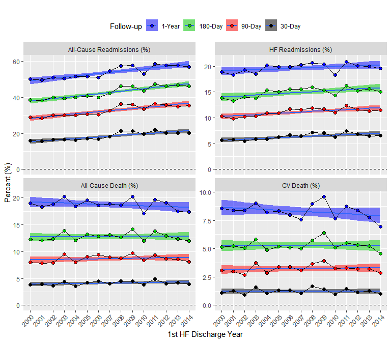

```r
# Save the table as CSV
table1.apx <- cbind.data.frame(t1a.apx,
                               t1b.apx[, -1],
                               t1c.apx[, -1],
                               t1d.apx[, -1])
tmp <- data.frame(matrix(c("HF Discharge Year",
                           rep(c("30-Day",
                                 "90-Day",
                                 "180-Day",
                                 "1-Year"),
                               4)),
                         nrow = 1))
colnames(tmp) <- colnames(table1.apx)

table1.apx <- rbind.data.frame(tmp,
                               table1.apx)
colnames(table1.apx) <- c("",
                          "All-Cause Readmissions (%)", "", "", "",
                          "HF Readmissions (%)", "", "", "",
                          "All-Cause Death (%)", "", "", "",
                          "CV Death (%)", "", "", "")

write.csv(table1.apx,
          file = "tmp/table1.apx.csv",
          row.names = FALSE)

# Clean memory
invisible({
  rm(tmp)
  gc()
})

# Plot rates----
t1.apx <- list(t1a.apx[-16, ],
               t1b.apx[-16, ],
               t1c.apx[-16, ],
               t1d.apx[-16, ])

names(t1.apx) <- c("All-Cause Readmissions (%)",
                      "HF Readmissions (%)",
                      "All-Cause Death (%)",
                      "CV Death (%)")

out <- list()
for (i in 1:length(t1.apx)) {
  out[[i]] <- melt.data.table(data = t1.apx[[i]],
                              id.vars = 1,
                              measure.vars = c(2:5),
                              variable.name = "followup",
                              value.name = "rate")
  out[[i]]$endpoint <- names(t1.apx)[[i]]
}

out <- do.call("rbind", out)

# Re-level follow-up
out$followup <- factor(out$followup,
                       levels = rev(levels(out$followup)))

# Endpoint as a factor
out$endpoint <- factor(out$endpoint,
                       levels = names(t1.apx))

# Figure 1: all rates----
p1 <- ggplot(data = out,
             aes(x = `HF Discharge Year`,
                 y = rate,
                 group = followup,
                 fill = followup)) +
  facet_wrap(~ endpoint,
             nrow = 2,
             scales = "free_y") +
  geom_smooth(method = "lm",
              alpha = 0.5) +
  geom_line(size = 0.5) +
  geom_point(size = 2,
             shape = 21) +
  geom_hline(yintercept = 0,
             linetype = "dashed") +
  scale_x_discrete("1st HF Discharge Year",
                   breaks = unique(out$`HF Discharge Year`),
                   labels = unique(out$`HF Discharge Year`)) +
  scale_y_continuous("Percent (%)") +
  ggtitle("") +
  scale_fill_manual(label = c("1-Year",
                              "180-Day",
                              "90-Day",
                              "30-Day"),
                    values = unique(out$followup)) +
  guides(fill = guide_legend(title = "Follow-up")) +
  theme(legend.position = "top",
        axis.text.x = element_text(angle = 45,
                                   hjust = 1),
        plot.title = element_text(hjust = 0))

# Save for publication
p2 <- p1 +
  ggtitle("") +
  theme(legend.position = "none")
tiff(filename = "tmp/fig2.tiff",
     height = 6,
     width = 7,
     units = "in",
     res = 600,
     compression = "lzw+p")
print(p2)
graphics.off()

print(p1)
```

```r
out <- list()
for (i in 1:length(t1.apx)) {
  tmp <- t1.apx[[i]]
  tmp$year <- as.numeric(as.character(tmp$`HF Discharge Year`)) - 2000
  m1 <- lm(`1-Year` ~ year,
           data = tmp)
  out[[i]] <- summary(m1)
}
names(out) <- names(t1.apx)
out
```

```
$`All-Cause Readmissions (%)`

Call:
lm(formula = `1-Year` ~ year, data = tmp)

Residuals:
    Min      1Q  Median      3Q     Max
-2.9169 -0.9208 -0.1024  0.7018  2.9635

Coefficients:
            Estimate Std. Error t value Pr(>|t|)
(Intercept)  49.3051     0.8465  58.244  < 2e-16 ***
year          0.6652     0.1029   6.464 2.12e-05 ***
---
Signif. codes:  0 ‘***’ 0.001 ‘**’ 0.01 ‘*’ 0.05 ‘.’ 0.1 ‘ ’ 1

Residual standard error: 1.722 on 13 degrees of freedom
Multiple R-squared:  0.7627,    Adjusted R-squared:  0.7444
F-statistic: 41.78 on 1 and 13 DF,  p-value: 2.12e-05


$`HF Readmissions (%)`

Call:
lm(formula = `1-Year` ~ year, data = tmp)

Residuals:
     Min       1Q   Median       3Q      Max
-1.61621 -0.46246  0.09236  0.55593  0.88771

Coefficients:
            Estimate Std. Error t value Pr(>|t|)
(Intercept) 19.05550    0.37555  50.741 2.48e-16 ***
year         0.08607    0.04565   1.885   0.0819 .
---
Signif. codes:  0 ‘***’ 0.001 ‘**’ 0.01 ‘*’ 0.05 ‘.’ 0.1 ‘ ’ 1

Residual standard error: 0.7639 on 13 degrees of freedom
Multiple R-squared:  0.2147,    Adjusted R-squared:  0.1543
F-statistic: 3.554 on 1 and 13 DF,  p-value: 0.08193
```

[output cut: 27 more lines]

```

Residuals:
    Min      1Q  Median      3Q     Max
-1.0076 -0.3201 -0.1643  0.4334  1.4155

Coefficients:
            Estimate Std. Error t value Pr(>|t|)
(Intercept)  8.65708    0.31869  27.165 7.75e-13 ***
year        -0.05139    0.03874  -1.327    0.207
---
Signif. codes:  0 ‘***’ 0.001 ‘**’ 0.01 ‘*’ 0.05 ‘.’ 0.1 ‘ ’ 1

Residual standard error: 0.6483 on 13 degrees of freedom
Multiple R-squared:  0.1192,    Adjusted R-squared:  0.05147
F-statistic:  1.76 on 1 and 13 DF,  p-value: 0.2075
```

# Causes for Readmission

```r
source("source/icd9_dx_get_data_v1.R")
dt.icd <- icd9cm_merge_version_dx(32)

map <- unique(data.table(readm.dx1 = dt.icd$code,
              major = dt.icd$major))

tmp <- case[readm == TRUE,
            c("Patient_ID",
              "readm.dx1",
              "days2readm")]
tmp <- merge(map,
             tmp,
             by = "readm.dx1")
readm_cause <- copy(tmp)

tmp30 <- tmp[days2readm < 31, ]
t30 <- data.table(table(tmp30$major))
t30$Percent <- round(100*t30$N/sum(t30$N), 1)
t30 <- t30[order(t30$N,
                 decreasing = TRUE),]
DT::datatable(t30,
              caption = "30-Day Readmissions by Cause (DX1)",
              class = "cell-border stripe",
              rownames = FALSE,
              options = list(searching = TRUE,
                             pageLength = 20))
```

| V1 | N | Percent |
| --- | --- | --- |
| Heart failure | 4262 | 25.5 |
| Other forms of chronic ischemic heart disease | 1076 | 6.4 |
| Cardiac dysrhythmias | 845 | 5.1 |
| Symptoms involving respiratory system and other chest symptoms | 506 | 3 |
| Acute kidney failure | 483 | 2.9 |
| Pneumonia, organism unspecified | 439 | 2.6 |
| Acute myocardial infarction | 433 | 2.6 |
| Other diseases of endocardium | 386 | 2.3 |
| General symptoms | 369 | 2.2 |
| Diabetes mellitus | 355 | 2.1 |

[output cut: 365 more lines]

```r
tmp90<- tmp[days2readm < 91, ]
t90 <- data.table(table(tmp90$major))
t90$Percent <- round(100*t90$N/sum(t90$N), 1)
t90 <- t90[order(t90$N,
                 decreasing = TRUE),]
DT::datatable(t90,
              caption = "90-Day Readmissions by Cause (DX1)",
              class = "cell-border stripe",
              rownames = FALSE,
              options = list(searching = TRUE,
                             pageLength = 20))
```

| V1 | N | Percent |
| --- | --- | --- |
| Heart failure | 7495 | 25.3 |
| Other forms of chronic ischemic heart disease | 1843 | 6.2 |
| Cardiac dysrhythmias | 1553 | 5.2 |
| Symptoms involving respiratory system and other chest symptoms | 846 | 2.9 |
| Pneumonia, organism unspecified | 791 | 2.7 |
| Acute myocardial infarction | 790 | 2.7 |
| Acute kidney failure | 770 | 2.6 |
| Diabetes mellitus | 669 | 2.3 |
| General symptoms | 632 | 2.1 |
| Other diseases of endocardium | 576 | 1.9 |

[output cut: 437 more lines]

```r
tmp180 <- tmp[days2readm < 181, ]
t180 <- data.table(table(tmp180$major))
t180$Percent <- round(100*t180$N/sum(t180$N), 1)
t180 <- t180[order(t180$N,
                 decreasing = TRUE),]
DT::datatable(t180,
              caption = "180-Day Readmissions by Cause (DX1)",
              class = "cell-border stripe",
              rownames = FALSE,
              options = list(searching = TRUE,
                             pageLength = 20))
```

| V1 | N | Percent |
| --- | --- | --- |
| Heart failure | 9550 | 24.5 |
| Other forms of chronic ischemic heart disease | 2295 | 5.9 |
| Cardiac dysrhythmias | 2037 | 5.2 |
| Symptoms involving respiratory system and other chest symptoms | 1210 | 3.1 |
| Acute myocardial infarction | 1054 | 2.7 |
| Pneumonia, organism unspecified | 1049 | 2.7 |
| Acute kidney failure | 943 | 2.4 |
| Diabetes mellitus | 931 | 2.4 |
| General symptoms | 856 | 2.2 |
| Septicemia | 683 | 1.8 |

[output cut: 467 more lines]

```r
tmp1y <- tmp[days2readm < 366, ]
t1y <- data.table(table(tmp1y$major))
t1y$Percent <- round(100*t1y$N/sum(t1y$N), 1)
t1y <- t1y[order(t1y$N,
                 decreasing = TRUE),]
t1y$N <- format(t1y$N,
                big.mark = ",")
DT::datatable(t1y,
              caption = "1-Year Readmissions by Cause (DX1)",
              class = "cell-border stripe",
              rownames = FALSE,
              options = list(searching = TRUE,
                             pageLength = 20))
```

| V1 | N | Percent |
| --- | --- | --- |
| Heart failure | 11,617 | 23.6 |
| Other forms of chronic ischemic heart disease | 2,659 | 5.4 |
| Cardiac dysrhythmias | 2,535 | 5.1 |
| Symptoms involving respiratory system and other chest symptoms | 1,565 | 3.2 |
| Pneumonia, organism unspecified | 1,413 | 2.9 |
| Acute myocardial infarction | 1,370 | 2.8 |
| Diabetes mellitus | 1,161 | 2.4 |
| General symptoms | 1,154 | 2.3 |
| Acute kidney failure | 1,133 | 2.3 |
| Chronic bronchitis | 913 | 1.9 |

[output cut: 498 more lines]

# Length of Stay

```r
# Length of stay
case$los <- as.numeric(difftime(case$DSCHDAT,
                     case$ADMDAT,
                     units = "days"))

# Distribution of length of stay
summary(case$los)
```

```
   Min. 1st Qu.  Median    Mean 3rd Qu.    Max.
  0.000   3.000   4.000   5.709   7.000 289.000
```

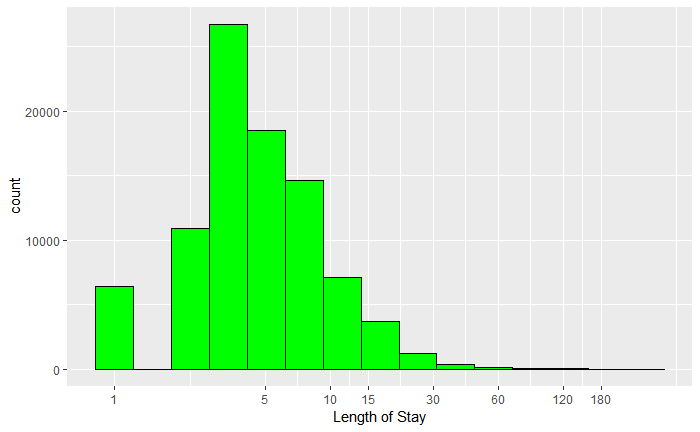

```r
p1 <- ggplot(case[ , "los"],
             aes(x = los)) +
  geom_histogram(bins = 15,
                 color = "black",
                 fill = "green") +
  scale_x_log10("Length of Stay",
                breaks = c(0, 1, 5, 10, 15, 30, 60, 120, 180))
p1
```

**NOTE***: 3,433 patients were discharged at the day of admission. This might include transfers to other hospitals but we did not look at transfers.

# Part III: Logistic Regression Models

```r
t2.names <- c("Discharge year",
              "Age (per 10 Years)",
              "Sex (Male)",
              "Race (Black)",
              "Race (Other)",
              "Non-Hispanic vs. Hispanic",
              "Unknown vs. Hispanic",
              "Commercial Insurance vs. Medicare",
              "Medicaid/Self-Pay/Other vs. Medicare",
              "Length of Stay",
              "AFib/AFlutter",
              "AMI",
              "Anemia",
              "CKD",
              "COPD",
              "Diabetes",
              "Hypertension",
              "Hyperlipidemia",
              "Sleep Apnea",
              "Parkinson",
              "Stroke",
              "TIA",
              "Hosp No Cath Lab vs. Cath Lab",
              # "Hosp Unknown vs. Cath Lab",
              "Hosp Inner City Area vs. Urban",
              "Hosp Rural Area vs. Urban",
              "Hosp Suburb Area vs. Urban",
              # "Hosp Unknown Area vs. Urban",
              "Hosp Non-Teaching vs. Teaching")
              # "Hosp Unknown vs. Teaching")

# Discharge year as numeric
case$DSCYR <- as.numeric(case$DSCYR)

# Remove patients from hosps with no info
paste(format(nrow(case[Area == "Unknown", ]),
             big.mark = ","),
      "patients are from hospitals with no info; REMOVE THEM")
```

```
[1] "3,353 patients are from hospitals with no info; REMOVE THEM"
```

```r
case1 <- copy(case)
case <- droplevels(case[Area != "Unknown", ])
```

## Correlations of binary variables

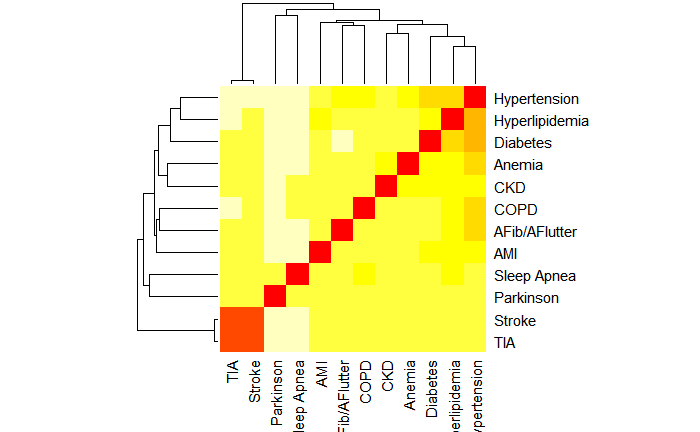

```r
tmp <- case[, haf:htia]
colnames(tmp) <- c("AFib/AFlutter",
                   "AMI",
                   "Anemia",
                   "CKD",
                   "COPD",
                   "Diabetes",
                   "Hypertension",
                   "Hyperlipidemia",
                   "Sleep Apnea",
                   "Parkinson",
                   "Stroke",
                   "TIA")
cor1 <- cor(tmp,
            use = "pairwise.complete.obs")
heatmap(cor1,
        col = rev(heat.colors(10)))
```

Stroke and TIA are highly correlated while hypertension is mildley correlated with hyperlipidemia, diabetes, COPD and AFib/AFlutter.

## All-Cause Readmissions

```r
case$readm30 <- case$readm90 <- case$readm180 <- case$readm1y <- FALSE
case$readm30[case$days2readm < 31] <- TRUE
case$readm90[case$days2readm < 91] <- TRUE
case$readm180[case$days2readm < 181] <- TRUE
case$readm1y[case$days2readm < 366] <- TRUE

m2a.30 <- glm(readm30 ~ DSCYR +
                decade +
                SEX +
                RACE +
                HISPAN +
                PRIME +
                los +
                haf +
                hami +
                hanemia  +
                hckd +
                hcopd +
                hdiab +
                hhyper +
                hlipid  +
                hosa +
                hpark +
                hstroke  +
                htia +
                CLAB +
                Area +
                Teach,
              family = binomial(logit),
              data = case)

m2a.90 <- glm(readm90 ~ DSCYR +
                decade +
                SEX +
                RACE +
                HISPAN +
                PRIME +
                los +
                haf +
                hami +
                hanemia  +
                hckd +
                hcopd +
                hdiab +
                hhyper +
                hlipid  +
                hosa +
                hpark +
                hstroke  +
                htia +
                CLAB +
                Area +
                Teach,
              family = binomial(logit),
              data = case)

m2a.180 <- glm(readm180 ~ DSCYR +
                 decade +
                 SEX +
                 RACE +
                 HISPAN +
                 PRIME +
                 los +
                 haf +
                 hami +
                 hanemia  +
                 hckd +
                 hcopd +
                 hdiab +
                 hhyper +
                 hlipid  +
                 hosa +
                 hpark +
                 hstroke  +
                 htia +
                 CLAB +
                 Area +
                 Teach,
               family = binomial(logit),
               data = case)

m2a.1y <- glm(readm1y ~ DSCYR +
                decade +
                SEX +
                RACE +
                HISPAN +
                PRIME +
                los +
                haf +
                hami +
                hanemia  +
                hckd +
                hcopd +
                hdiab +
                hhyper +
                hlipid  +
                hosa +
                hpark +
                hstroke  +
                htia +
                CLAB +
                Area +
                Teach,
              family = binomial(logit),
              data = case)

# Combine
s2a <- list(summary(m2a.30),
            summary(m2a.90),
            summary(m2a.180),
            summary(m2a.1y))

t2a <- lapply(s2a, function(a) {
  out <- data.table(names = t2.names,
                    coef = exp(a$coefficients[-1, 1]),
                    lb = exp(a$coefficients[-1, 1] - 1.96*a$coefficients[-1, 2]),
                    ub = exp(a$coefficients[-1, 1] + 1.96*a$coefficients[-1, 2]),
                    pval = ifelse(a$coefficients[-1, 4] >= 0.001,
                                  round(a$coefficients[-1, 4], 3),
                                  "<0.001"),
                    sign = ifelse(a$coefficients[-1, 4] <= 0.05,
                                  ifelse(a$coefficients[-1, 4] <= 0.01,
                                         "**",
                                         "*"), ""))
  rownames(out) <- NULL
  return(out)
})

t2a <- do.call("rbind", t2a)

t2a <- data.table(followup = rep(c("30-Day",
                                   "90-Day",
                                   "180-Day",
                                   "1-Year"),
                                 each = length(t2.names)),
                  t2a)
t2a$names <- factor(t2a$names,
                    levels = unique(t2a$names))
t2a$followup <- factor(as.character(t2a$followup),
                       levels = c("30-Day",
                                  "90-Day",
                                  "180-Day",
                                  "1-Year"))

# Save Table 2A as CSV
t2a$est <- paste(round(t2a$coef, 3),
                 " (",
                 round(t2a$lb, 3),
                 ", ",
                 round(t2a$ub, 3),
                 ")\n",
                 t2a$pval,
                 sep = "")
table2a <- dcast.data.table(data = t2a,
                            names ~ followup,
                            value.var = "est")
colnames(table2a)[1] <- "Risk Factor"

write.csv(table2a,
          file = "tmp/table2a.csv",
          row.names = FALSE)

DT::datatable(table2a,
              caption = "Table2A: All-Cause Readmissions",
              rownames = FALSE,
              options = list(searching = TRUE,
                             pageLength = nrow(table2a)))
```

| Risk Factor | 30-Day | 90-Day | 180-Day | 1-Year |
| --- | --- | --- | --- | --- |
| Discharge year | 1.023 (1.019, 1.028) &lt;0.001 | 1.02 (1.017, 1.024) &lt;0.001 | 1.019 (1.016, 1.022) &lt;0.001 | 1.013 (1.01, 1.017) &lt;0.001 |
| Age (per 10 Years) | 0.997 (0.983, 1.012) 0.709 | 0.99 (0.978, 1.002) 0.098 | 0.975 (0.964, 0.987) &lt;0.001 | 0.97 (0.959, 0.982) &lt;0.001 |
| Sex (Male) | 0.991 (0.956, 1.027) 0.614 | 0.995 (0.966, 1.025) 0.748 | 0.994 (0.967, 1.023) 0.688 | 0.979 (0.952, 1.007) 0.137 |
| Race (Black) | 0.972 (0.921, 1.024) 0.285 | 1.052 (1.007, 1.099) 0.023 | 1.118 (1.072, 1.165) &lt;0.001 | 1.152 (1.105, 1.201) &lt;0.001 |
| Race (Other) | 0.969 (0.914, 1.028) 0.297 | 0.919 (0.874, 0.965) &lt;0.001 | 0.932 (0.889, 0.976) 0.003 | 0.927 (0.885, 0.971) 0.001 |
| Non-Hispanic vs. Hispanic | 0.934 (0.875, 0.997) 0.042 | 0.834 (0.79, 0.881) &lt;0.001 | 0.842 (0.799, 0.887) &lt;0.001 | 0.844 (0.801, 0.89) &lt;0.001 |
| Unknown vs. Hispanic | 0.868 (0.797, 0.945) 0.001 | 0.794 (0.741, 0.852) &lt;0.001 | 0.8 (0.749, 0.855) &lt;0.001 | 0.806 (0.754, 0.861) &lt;0.001 |
| Commercial Insurance vs. Medicare | 0.883 (0.844, 0.924) &lt;0.001 | 0.873 (0.84, 0.906) &lt;0.001 | 0.857 (0.827, 0.888) &lt;0.001 | 0.853 (0.824, 0.884) &lt;0.001 |
| Medicaid/Self-Pay/Other vs. Medicare | 1.001 (0.928, 1.079) 0.986 | 0.96 (0.901, 1.022) 0.197 | 0.931 (0.877, 0.988) 0.018 | 0.933 (0.879, 0.989) 0.02 |
| Length of Stay | 1.019 (1.016, 1.021) &lt;0.001 | 1.019 (1.016, 1.021) &lt;0.001 | 1.014 (1.012, 1.017) &lt;0.001 | 1.007 (1.005, 1.01) &lt;0.001 |

[output cut: 17 more lines]

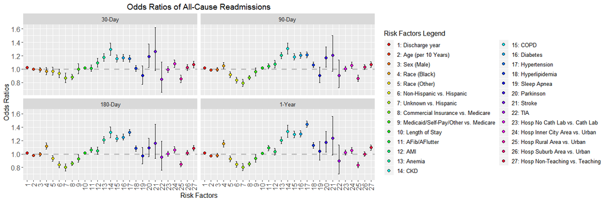

```r
# Plot OR----
p2a <- ggplot(t2a,
              aes(x = names,
                  y = coef)) +
  facet_wrap( ~ followup,
              ncol = 2) +
  geom_hline(yintercept = 1,
             colour = "grey",
             size = 1.1,
             linetype = 2) +
  geom_errorbar(aes(ymin = lb,
                    ymax = ub),
                size = 0.4,
                width = 0.2) +
  geom_point(aes(x = names,
                 y = coef,
                 fill = names),
             size = 2,
             shape = 21) +
  scale_fill_manual(labels = paste(1:nlevels(t2a$names),
                                   levels(t2a$names),
                                   sep = ": "),
                    values = rainbow(nlevels(t2a$names))) +
  scale_x_discrete("Risk Factors",
                   labels = 1:nlevels(t2a$names)) +
  scale_y_continuous("Odds Ratios") +
  ggtitle("Odds Ratios of All-Cause Readmissions") +
  theme(axis.text.x = element_text(angle = 90,
                                   size = 12,
                                   hjust = 1,
                                   vjust = 0.5),
        axis.text.y = element_text(size = 12),
        text = element_text(size = 12),
        plot.title = element_text(hjust = 0.5)) +
  guides(fill = guide_legend("Risk Factors Legend"))

# Save for publication
ppp2a <- p2a +
  ggtitle("") +
  theme(legend.position = "none")
tiff(filename = "tmp/fig3.tiff",
     height = 6,
     width = 10,
     units = "in",
     res = 600,
     compression = "lzw+p")
print(ppp2a)
graphics.off()

print(p2a)
```

## HF Cause Readmissions

```r
# Publication/Table 2a: All-cause readmissions----
case$hf30 <- case$hf90 <- case$hf180 <- case$hf1y <- FALSE
case$hf30[case$days2post.hf.dx1 < 31] <- TRUE
case$hf90[case$days2post.hf.dx1 < 91] <- TRUE
case$hf180[case$days2post.hf.dx1 < 181] <- TRUE
case$hf1y[case$days2post.hf.dx1 < 366] <- TRUE

m2b.30 <- glm(hf30 ~ DSCYR +
                decade +
                SEX +
                RACE +
                HISPAN +
                PRIME +
                los +
                haf +
                hami +
                hanemia  +
                hckd +
                hcopd +
                hdiab +
                hhyper +
                hlipid  +
                hosa +
                hpark +
                hstroke  +
                htia +
                CLAB +
                Area +
                Teach,
              family = binomial(logit),
              data = case)

m2b.90 <- glm(hf90 ~ DSCYR +
                decade +
                SEX +
                RACE +
                HISPAN +
                PRIME +
                los +
                haf +
                hami +
                hanemia  +
                hckd +
                hcopd +
                hdiab +
                hhyper +
                hlipid  +
                hosa +
                hpark +
                hstroke  +
                htia +
                CLAB +
                Area +
                Teach,
              family = binomial(logit),
              data = case)

m2b.180 <- glm(hf180 ~ DSCYR +
                decade +
                SEX +
                RACE +
                HISPAN +
                PRIME +
                los +
                haf +
                hami +
                hanemia  +
                hckd +
                hcopd +
                hdiab +
                hhyper +
                hlipid  +
                hosa +
                hpark +
                hstroke  +
                htia +
                CLAB +
                Area +
                Teach,
               family = binomial(logit),
               data = case)

m2b.1y <- glm(hf1y ~ DSCYR +
                decade +
                SEX +
                RACE +
                HISPAN +
                PRIME +
                los +
                haf +
                hami +
                hanemia  +
                hckd +
                hcopd +
                hdiab +
                hhyper +
                hlipid  +
                hosa +
                hpark +
                hstroke  +
                htia +
                CLAB +
                Area +
                Teach,
              family = binomial(logit),
              data = case)

# Combine
s2b <- list(summary(m2b.30),
            summary(m2b.90),
            summary(m2b.180),
            summary(m2b.1y))

t2b <- lapply(s2b, function(a) {
  out <- data.table(names = t2.names,
                    coef = exp(a$coefficients[-1, 1]),
                    lb = exp(a$coefficients[-1, 1] - 1.96*a$coefficients[-1, 2]),
                    ub = exp(a$coefficients[-1, 1] + 1.96*a$coefficients[-1, 2]),
                    pval = ifelse(a$coefficients[-1, 4] >= 0.001,
                                  round(a$coefficients[-1, 4], 3),
                                  "<0.001"),
                    sign = ifelse(a$coefficients[-1, 4] <= 0.05,
                                  ifelse(a$coefficients[-1, 4] <= 0.01,
                                         "**",
                                         "*"), ""))
  rownames(out) <- NULL
  return(out)
})

t2b <- do.call("rbind", t2b)

t2b <- data.table(followup = rep(c("30-Day",
                                   "90-Day",
                                   "180-Day",
                                   "1-Year"),
                                 each = length(t2.names)),
                  t2b)
t2b$names <- factor(t2b$names,
                    levels = unique(t2b$names))
t2b$followup <- factor(as.character(t2b$followup),
                       levels = c("30-Day",
                                  "90-Day",
                                  "180-Day",
                                  "1-Year"))

# Save Table 2A as CSV
t2b$est <- paste(round(t2b$coef, 3),
                 " (",
                 round(t2b$lb, 3),
                 ", ",
                 round(t2b$ub, 3),
                 ")\n",
                 t2b$pval,
                 sep = "")
table2b <- dcast.data.table(data = t2b,
                            names ~ followup,
                            value.var = "est")
colnames(table2b)[1] <- "Risk Factor"

write.csv(table2b,
          file = "tmp/table2b.csv",
          row.names = FALSE)

DT::datatable(table2b,
              caption = "Table2B: All-Cause Readmissions",
              rownames = FALSE,
              options = list(searching = TRUE,
                             pageLength = nrow(table2b)))
```

| Risk Factor | 30-Day | 90-Day | 180-Day | 1-Year |
| --- | --- | --- | --- | --- |
| Discharge year | 1.016 (1.009, 1.022) &lt;0.001 | 1.01 (1.005, 1.015) &lt;0.001 | 1.008 (1.003, 1.012) 0.001 | 1.001 (0.997, 1.005) 0.776 |
| Age (per 10 Years) | 0.937 (0.916, 0.958) &lt;0.001 | 0.979 (0.962, 0.997) 0.019 | 0.989 (0.974, 1.005) 0.171 | 0.993 (0.979, 1.008) 0.361 |
| Sex (Male) | 1.116 (1.055, 1.18) &lt;0.001 | 1.085 (1.039, 1.134) &lt;0.001 | 1.079 (1.038, 1.121) &lt;0.001 | 1.08 (1.043, 1.118) &lt;0.001 |
| Race (Black) | 1.079 (0.995, 1.171) 0.067 | 1.178 (1.106, 1.254) &lt;0.001 | 1.258 (1.191, 1.329) &lt;0.001 | 1.316 (1.253, 1.383) &lt;0.001 |
| Race (Other) | 0.94 (0.856, 1.033) 0.201 | 0.925 (0.86, 0.996) 0.039 | 0.925 (0.866, 0.987) 0.018 | 0.974 (0.919, 1.032) 0.371 |
| Non-Hispanic vs. Hispanic | 0.822 (0.745, 0.907) &lt;0.001 | 0.78 (0.723, 0.842) &lt;0.001 | 0.781 (0.73, 0.836) &lt;0.001 | 0.791 (0.744, 0.841) &lt;0.001 |
| Unknown vs. Hispanic | 0.726 (0.636, 0.829) &lt;0.001 | 0.718 (0.649, 0.795) &lt;0.001 | 0.732 (0.669, 0.8) &lt;0.001 | 0.73 (0.673, 0.792) &lt;0.001 |
| Commercial Insurance vs. Medicare | 0.923 (0.859, 0.991) 0.028 | 0.907 (0.858, 0.96) &lt;0.001 | 0.893 (0.85, 0.938) &lt;0.001 | 0.883 (0.845, 0.923) &lt;0.001 |
| Medicaid/Self-Pay/Other vs. Medicare | 1.162 (1.041, 1.297) 0.007 | 1.234 (1.132, 1.345) &lt;0.001 | 1.177 (1.09, 1.272) &lt;0.001 | 1.159 (1.081, 1.244) &lt;0.001 |
| Length of Stay | 1.007 (1.003, 1.011) 0.001 | 1.006 (1.002, 1.009) &lt;0.001 | 1.005 (1.002, 1.008) 0.002 | 1.002 (0.999, 1.005) 0.11 |

[output cut: 17 more lines]

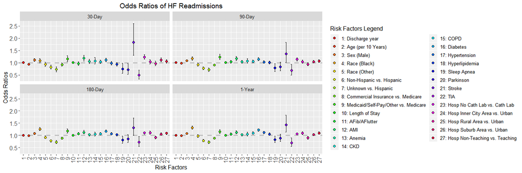

```r
# Plot OR----
p2b <- ggplot(t2b,
              aes(x = names,
                  y = coef)) +
  facet_wrap( ~ followup,
              ncol = 2) +
  geom_hline(yintercept = 1,
             colour = "grey",
             size = 1.1,
             linetype = 2) +
  geom_errorbar(aes(ymin = lb,
                    ymax = ub),
                size = 0.4,
                width = 0.2) +
  geom_point(aes(x = names,
                 y = coef,
                 fill = names),
             size = 2,
             shape = 21) +
  scale_fill_manual(labels = paste(1:nlevels(t2a$names),
                                   levels(t2a$names),
                                   sep = ": "),
                    values = rainbow(nlevels(t2a$names))) +
  scale_x_discrete("Risk Factors",
                   labels = 1:nlevels(t2a$names)) +
  scale_y_continuous("Odds Ratios") +
  ggtitle("Odds Ratios of HF Readmissions") +
  theme(axis.text.x = element_text(angle = 90,
                                   size = 12,
                                   hjust = 1,
                                   vjust = 0.5),
        axis.text.y = element_text(size = 12),
        text = element_text(size = 12),
        plot.title = element_text(hjust = 0.5)) +
  guides(fill = guide_legend("Risk Factors Legend"))

# Save for publication
ppp2b <- p2b +
  ggtitle("") +
  theme(legend.position = "none")
tiff(filename = "tmp/fig5.tiff",
     height = 6,
     width = 10,
     units = "in",
     res = 600,
     compression = "lzw+p")
print(ppp2b)
graphics.off()

print(p2b)
```

## All-Cause Death

```r
# Publication/Table 2c: All-cause death----
case$dead30 <- case$dead90 <- case$dead180 <- case$dead1y <- FALSE
case$dead30[case$days2death < 31] <- TRUE
case$dead90[case$days2death < 91] <- TRUE
case$dead180[case$days2death < 181] <- TRUE
case$dead1y[case$days2death < 366] <- TRUE

m2c.30 <- glm(dead30 ~ DSCYR +
                decade +
                SEX +
                RACE +
                HISPAN +
                PRIME +
                los +
                haf +
                hami +
                hanemia  +
                hckd +
                hcopd +
                hdiab +
                hhyper +
                hlipid  +
                hosa +
                hpark +
                hstroke  +
                htia +
                CLAB +
                Area +
                Teach,
              family = binomial(logit),
              data = case)

m2c.90 <- glm(dead90 ~ DSCYR +
                decade +
                SEX +
                RACE +
                HISPAN +
                PRIME +
                los +
                haf +
                hami +
                hanemia  +
                hckd +
                hcopd +
                hdiab +
                hhyper +
                hlipid  +
                hosa +
                hpark +
                hstroke  +
                htia +
                CLAB +
                Area +
                Teach,
              family = binomial(logit),
              data = case)

m2c.180 <- glm(dead180 ~ DSCYR +
                decade +
                SEX +
                RACE +
                HISPAN +
                PRIME +
                los +
                haf +
                hami +
                hanemia  +
                hckd +
                hcopd +
                hdiab +
                hhyper +
                hlipid  +
                hosa +
                hpark +
                hstroke  +
                htia +
                CLAB +
                Area +
                Teach,
               family = binomial(logit),
               data = case)

m2c.1y <- glm(dead1y ~ DSCYR +
                decade +
                SEX +
                RACE +
                HISPAN +
                PRIME +
                los +
                haf +
                hami +
                hanemia  +
                hckd +
                hcopd +
                hdiab +
                hhyper +
                hlipid  +
                hosa +
                hpark +
                hstroke  +
                htia +
                CLAB +
                Area +
                Teach,
              family = binomial(logit),
              data = case)

# Combine
s2c <- list(summary(m2c.30),
            summary(m2c.90),
            summary(m2c.180),
            summary(m2c.1y))

t2c <- lapply(s2c, function(a) {
  out <- data.table(names = t2.names,
                    coef = exp(a$coefficients[-1, 1]),
                    lb = exp(a$coefficients[-1, 1] - 1.96*a$coefficients[-1, 2]),
                    ub = exp(a$coefficients[-1, 1] + 1.96*a$coefficients[-1, 2]),
                    pval = ifelse(a$coefficients[-1, 4] >= 0.001,
                                  round(a$coefficients[-1, 4], 3),
                                  "<0.001"),
                    sign = ifelse(a$coefficients[-1, 4] <= 0.05,
                                  ifelse(a$coefficients[-1, 4] <= 0.01,
                                         "**",
                                         "*"), ""))
  rownames(out) <- NULL
  return(out)
})

t2c <- do.call("rbind", t2c)

t2c <- data.table(followup = rep(c("30-Day",
                                   "90-Day",
                                   "180-Day",
                                   "1-Year"),
                                 each = length(t2.names)),
                  t2c)
t2c$names <- factor(t2a$names,
                    levels = unique(t2c$names))
t2c$followup <- factor(as.character(t2c$followup),
                       levels = c("30-Day",
                                  "90-Day",
                                  "180-Day",
                                  "1-Year"))

# Save Table 2C as CSV
t2c$est <- paste(round(t2c$coef, 3),
                 " (",
                 round(t2c$lb, 3),
                 ", ",
                 round(t2c$ub, 3),
                 ")\n",
                 t2c$pval,
                 sep = "")
table2c <- dcast.data.table(data = t2c,
                            names ~ followup,
                            value.var = "est")
colnames(table2c)[1] <- "Risk Factor"

write.csv(table2c,
          file = "tmp/table2c.csv",
          row.names = FALSE)

DT::datatable(table2c,
              caption = "Table2C: All-Cause Death",
              rownames = FALSE,
              options = list(searching = TRUE,
                             pageLength = nrow(table2c)))
```

| Risk Factor | 30-Day | 90-Day | 180-Day | 1-Year |
| --- | --- | --- | --- | --- |
| Discharge year | 1.014 (1.005, 1.022) 0.001 | 1.011 (1.005, 1.017) &lt;0.001 | 1.005 (1, 1.01) 0.047 | 0.997 (0.993, 1.001) 0.183 |
| Age (per 10 Years) | 1.68 (1.622, 1.741) &lt;0.001 | 1.644 (1.604, 1.686) &lt;0.001 | 1.624 (1.591, 1.658) &lt;0.001 | 1.605 (1.577, 1.634) &lt;0.001 |
| Sex (Male) | 1.162 (1.083, 1.247) &lt;0.001 | 1.151 (1.094, 1.21) &lt;0.001 | 1.162 (1.114, 1.213) &lt;0.001 | 1.163 (1.121, 1.206) &lt;0.001 |
| Race (Black) | 0.711 (0.621, 0.813) &lt;0.001 | 0.771 (0.704, 0.844) &lt;0.001 | 0.801 (0.744, 0.863) &lt;0.001 | 0.854 (0.803, 0.908) &lt;0.001 |
| Race (Other) | 0.769 (0.671, 0.882) &lt;0.001 | 0.797 (0.725, 0.876) &lt;0.001 | 0.786 (0.726, 0.851) &lt;0.001 | 0.805 (0.753, 0.861) &lt;0.001 |
| Non-Hispanic vs. Hispanic | 1.396 (1.18, 1.652) &lt;0.001 | 1.362 (1.214, 1.528) &lt;0.001 | 1.412 (1.283, 1.554) &lt;0.001 | 1.445 (1.333, 1.566) &lt;0.001 |
| Unknown vs. Hispanic | 1.387 (1.137, 1.691) 0.001 | 1.37 (1.195, 1.571) &lt;0.001 | 1.387 (1.236, 1.556) &lt;0.001 | 1.391 (1.262, 1.533) &lt;0.001 |
| Commercial Insurance vs. Medicare | 0.843 (0.762, 0.932) &lt;0.001 | 0.84 (0.783, 0.902) &lt;0.001 | 0.839 (0.791, 0.89) &lt;0.001 | 0.812 (0.773, 0.854) &lt;0.001 |
| Medicaid/Self-Pay/Other vs. Medicare | 0.858 (0.682, 1.079) 0.19 | 0.801 (0.684, 0.938) 0.006 | 0.865 (0.763, 0.98) 0.023 | 0.894 (0.808, 0.989) 0.03 |
| Length of Stay | 1.048 (1.043, 1.052) &lt;0.001 | 1.058 (1.054, 1.062) &lt;0.001 | 1.057 (1.054, 1.061) &lt;0.001 | 1.054 (1.051, 1.057) &lt;0.001 |

[output cut: 17 more lines]

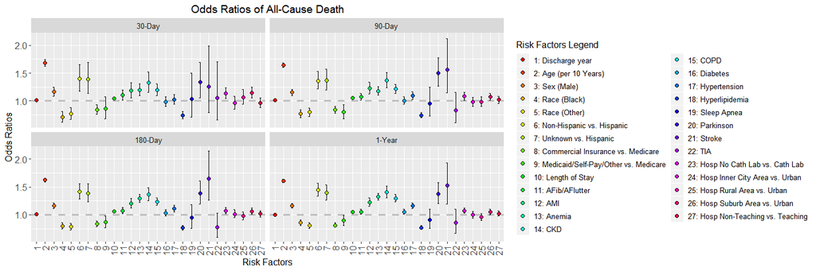

```r
# Plot OR----
p2c <- ggplot(t2c,
              aes(x = names,
                  y = coef)) +
  facet_wrap( ~ followup,
              ncol = 2) +
  geom_hline(yintercept = 1,
             colour = "grey",
             size = 1.1,
             linetype = 2) +
  geom_errorbar(aes(ymin = lb,
                    ymax = ub),
                size = 0.4,
                width = 0.2) +
  geom_point(aes(x = names,
                 y = coef,
                 fill = names),
             size = 2,
             shape = 21) +
  scale_fill_manual(labels = paste(1:nlevels(t2c$names),
                                   levels(t2c$names),
                                   sep = ": "),
                    values = rainbow(nlevels(t2c$names))) +
  scale_x_discrete("Risk Factors",
                   labels = 1:nlevels(t2c$names)) +
  scale_y_continuous("Odds Ratios") +
  ggtitle("Odds Ratios of All-Cause Death") +
  theme(axis.text.x = element_text(angle = 90,
                                   size = 12,
                                   hjust = 1,
                                   vjust = 0.5),
        axis.text.y = element_text(size = 12),
        text = element_text(size = 12),
        plot.title = element_text(hjust = 0.5)) +
  guides(fill = guide_legend("Risk Factors Legend"))

# Save for publication
ppp2c <- p2c +
  ggtitle("") +
  theme(legend.position = "none")
tiff(filename = "tmp/fig6.tiff",
     height = 6,
     width = 10,
     units = "in",
     res = 600,
     compression = "lzw+p")
print(ppp2c)
graphics.off()

print(p2c)
```

## CV Death

```r
# Publication/Table 2d: All-cause readmissions----
case$cvdeath30 <- case$cvdeath90 <- case$cvdeath180 <- case$cvdeath1y <- FALSE
case$cvdeath30[case$days2cvdeath < 31] <- TRUE
case$cvdeath90[case$days2cvdeath < 91] <- TRUE
case$cvdeath180[case$days2cvdeath < 181] <- TRUE
case$cvdeath1y[case$days2cvdeath < 366] <- TRUE

m2d.30 <- glm(cvdeath30 ~ DSCYR +
                decade +
                SEX +
                RACE +
                HISPAN +
                PRIME +
                los +
                haf +
                hami +
                hanemia  +
                hckd +
                hcopd +
                hdiab +
                hhyper +
                hlipid  +
                hosa +
                hpark +
                hstroke  +
                htia +
                CLAB +
                Area +
                Teach,
              family = binomial(logit),
              data = case)

m2d.90 <- glm(cvdeath90 ~ DSCYR +
                decade +
                SEX +
                RACE +
                HISPAN +
                PRIME +
                los +
                haf +
                hami +
                hanemia  +
                hckd +
                hcopd +
                hdiab +
                hhyper +
                hlipid  +
                hosa +
                hpark +
                hstroke  +
                htia +
                CLAB +
                Area +
                Teach,
              family = binomial(logit),
              data = case)

m2d.180 <- glm(cvdeath180 ~ DSCYR +
                decade +
                SEX +
                RACE +
                HISPAN +
                PRIME +
                los +
                haf +
                hami +
                hanemia  +
                hckd +
                hcopd +
                hdiab +
                hhyper +
                hlipid  +
                hosa +
                hpark +
                hstroke  +
                htia +
                CLAB +
                Area +
                Teach,
               family = binomial(logit),
               data = case)

m2d.1y <- glm(cvdeath1y ~ DSCYR +
                decade +
                SEX +
                RACE +
                HISPAN +
                PRIME +
                los +
                haf +
                hami +
                hanemia  +
                hckd +
                hcopd +
                hdiab +
                hhyper +
                hlipid  +
                hosa +
                hpark +
                hstroke  +
                htia +
                CLAB +
                Area +
                Teach,
              family = binomial(logit),
              data = case)

# Combine
s2d <- list(summary(m2d.30),
            summary(m2d.90),
            summary(m2d.180),
            summary(m2d.1y))

t2d <- lapply(s2d, function(a) {
  out <- data.table(names = t2.names,
                    coef = exp(a$coefficients[-1, 1]),
                    lb = exp(a$coefficients[-1, 1] - 1.96*a$coefficients[-1, 2]),
                    ub = exp(a$coefficients[-1, 1] + 1.96*a$coefficients[-1, 2]),
                    pval = ifelse(a$coefficients[-1, 4] >= 0.001,
                                  round(a$coefficients[-1, 4], 3),
                                  "<0.001"),
                    sign = ifelse(a$coefficients[-1, 4] <= 0.05,
                                  ifelse(a$coefficients[-1, 4] <= 0.01,
                                         "**",
                                         "*"), ""))
  rownames(out) <- NULL
  return(out)
})

t2d <- do.call("rbind", t2d)

t2d <- data.table(followup = rep(c("30-Day",
                                   "90-Day",
                                   "180-Day",
                                   "1-Year"),
                                 each = length(t2.names)),
                  t2d)
t2d$names <- factor(t2d$names,
                    levels = unique(t2d$names))
t2d$followup <- factor(as.character(t2d$followup),
                       levels = c("30-Day",
                                  "90-Day",
                                  "180-Day",
                                  "1-Year"))

# Save Table 2D as CSV
t2d$est <- paste(round(t2d$coef, 3),
                 " (",
                 round(t2d$lb, 3),
                 ", ",
                 round(t2d$ub, 3),
                 ")\n",
                 t2d$pval,
                 sep = "")
table2d <- dcast.data.table(data = t2d,
                            names ~ followup,
                            value.var = "est")
colnames(table2d)[1] <- "Risk Factor"

write.csv(table2d,
          file = "tmp/table2d.csv",
          row.names = FALSE)

DT::datatable(table2d,
              caption = "Table2D: CV Death",
              rownames = FALSE,
              options = list(searching = TRUE,
                             pageLength = nrow(table2d)))
```

| Risk Factor | 30-Day | 90-Day | 180-Day | 1-Year |
| --- | --- | --- | --- | --- |
| Discharge year | 1.008 (0.993, 1.023) 0.296 | 1.009 (0.999, 1.018) 0.067 | 1 (0.993, 1.008) 0.942 | 0.992 (0.986, 0.998) 0.01 |
| Age (per 10 Years) | 1.414 (1.332, 1.501) &lt;0.001 | 1.518 (1.462, 1.577) &lt;0.001 | 1.539 (1.493, 1.586) &lt;0.001 | 1.529 (1.492, 1.566) &lt;0.001 |
| Sex (Male) | 1.2 (1.061, 1.359) 0.004 | 1.13 (1.045, 1.222) 0.002 | 1.155 (1.086, 1.229) &lt;0.001 | 1.17 (1.112, 1.23) &lt;0.001 |
| Race (Black) | 0.642 (0.503, 0.819) &lt;0.001 | 0.835 (0.726, 0.961) 0.012 | 0.813 (0.728, 0.907) &lt;0.001 | 0.884 (0.81, 0.964) 0.005 |
| Race (Other) | 0.772 (0.608, 0.982) 0.035 | 0.872 (0.754, 1.008) 0.064 | 0.844 (0.752, 0.948) 0.004 | 0.896 (0.817, 0.982) 0.019 |
| Non-Hispanic vs. Hispanic | 1.6 (1.174, 2.181) 0.003 | 1.495 (1.239, 1.803) &lt;0.001 | 1.528 (1.319, 1.771) &lt;0.001 | 1.461 (1.301, 1.64) &lt;0.001 |
| Unknown vs. Hispanic | 1.671 (1.168, 2.389) 0.005 | 1.569 (1.261, 1.951) &lt;0.001 | 1.517 (1.276, 1.803) &lt;0.001 | 1.408 (1.227, 1.616) &lt;0.001 |
| Commercial Insurance vs. Medicare | 0.744 (0.622, 0.891) 0.001 | 0.8 (0.716, 0.895) &lt;0.001 | 0.834 (0.764, 0.91) &lt;0.001 | 0.814 (0.758, 0.873) &lt;0.001 |
| Medicaid/Self-Pay/Other vs. Medicare | 0.742 (0.503, 1.095) 0.133 | 0.795 (0.625, 1.013) 0.063 | 0.885 (0.735, 1.064) 0.193 | 0.856 (0.739, 0.992) 0.038 |
| Length of Stay | 1.03 (1.025, 1.035) &lt;0.001 | 1.035 (1.031, 1.039) &lt;0.001 | 1.032 (1.028, 1.036) &lt;0.001 | 1.029 (1.026, 1.033) &lt;0.001 |

[output cut: 17 more lines]

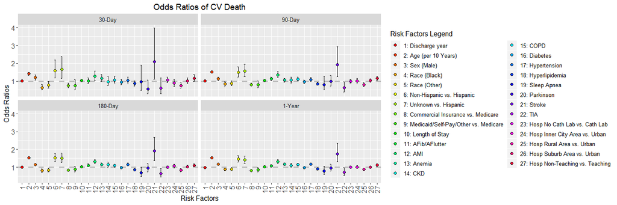

```r
# Plot OR----
p2d <- ggplot(t2d,
              aes(x = names,
                  y = coef)) +
  facet_wrap( ~ followup,
              ncol = 2) +
  geom_hline(yintercept = 1,
             colour = "grey",
             size = 1.1,
             linetype = 2) +
  geom_errorbar(aes(ymin = lb,
                    ymax = ub),
                size = 0.4,
                width = 0.2) +
  geom_point(aes(x = names,
                 y = coef,
                 fill = names),
             size = 2,
             shape = 21) +
  scale_fill_manual(labels = paste(1:nlevels(t2a$names),
                                   levels(t2a$names),
                                   sep = ": "),
                    values = rainbow(nlevels(t2a$names))) +
  scale_x_discrete("Risk Factors",
                   labels = 1:nlevels(t2a$names)) +
  scale_y_continuous("Odds Ratios") +
  ggtitle("Odds Ratios of CV Death") +
  theme(axis.text.x = element_text(angle = 90,
                                   size = 12,
                                   hjust = 1,
                                   vjust = 0.5),
        axis.text.y = element_text(size = 12),
        text = element_text(size = 12),
        plot.title = element_text(hjust = 0.5)) +
  guides(fill = guide_legend("Risk Factors Legend"))

# Save for publication
ppp2d <- p2d +
  ggtitle("") +
  theme(legend.position = "none")
tiff(filename = "tmp/fig7.tiff",
     height = 6,
     width = 10,
     units = "in",
     res = 600,
     compression = "lzw+p")
print(ppp2d)
graphics.off()

p2d
```

# Additional Analysis: Effect of Readmission for Specific Reason on 1-Year All-Cause Mortality

```r
nrow(tmp1y)
```

```
[1] 49224
```

```r
# 49,224

readm_grp <- fread("data/HF readmissions by cause.csv")
datatable(readm_grp,
          options = list(pageLength = nrow(readm_grp)))
```

|  | major | group |
| --- | --- | --- |
| 1 | Cardiac dysrhythmias | Arrhythmia |
| 2 | Occlusion of cerebral arteries | Cerebrovascular |
| 3 | Diabetes mellitus | Diabetes mellitus |
| 4 | General symptoms | General symptoms |
| 5 | Heart failure | Heart failure |
| 6 | Other forms of chronic ischemic heart disease | Heart Disease |
| 7 | Acute myocardial infarction | Heart Disease |
| 8 | Other diseases of endocardium | Heart Disease |
| 9 | Hypertensive heart disease | Hypertension |
| 10 | Hypertensive heart and chronic kidney disease | Hypertension |

[output cut: 11 more lines]

```r
readm1y <- merge(readm_grp,
                 tmp1y,
                 by = "major")
readm1y$days2readm <- NULL
readm1y$readm.dx1 <- NULL

case1$dead1y <- FALSE
case1$dead1y[case1$days2death < 366] <- TRUE

case2 <- merge(case1,
               readm1y,
               by = "Patient_ID",
               all.x = TRUE)

case2$group[is.na(case2$group)] <- "Other Reason"
case2$group[case2$days2readm > 365 |
              is.na(case2$days2readm)] <- "Not Readmitted"
case2$group <- factor(case2$group,
                      levels = c("Heart failure",
                                 "Not Readmitted",
                                 "Heart Disease",
                                 "Respiratory",
                                 "Kidney Disease",
                                 "Arrhythmia",
                                 "Infections",
                                 "Diabetes mellitus",
                                 "General symptoms",
                                 "Hypertension",
                                 "Procedures",
                                 "Cerebrovascular",
                                 "Other Reason"))

case2$dead1y[case2$days2death < 366] <- TRUE
case2$dead1y[is.na(case2$dead1y)] <- FALSE

tab7 <- addmargins(table(case2$group,
                         case2$dead1y))

tab7b <- data.table(Reason = rownames(tab7),
                    Alive = format(tab7[, 1],
                                   big.mark = ","),
                    Alive_Pct = round(100*tab7[, 1]/tab7[, 3], 1),
                    Dead = format(tab7[, 2],
                                  big.mark = ","),
                    Dead_Pct = round(100*tab7[, 2]/tab7[, 3], 1),
                    Total = format(tab7[, 3],
                                     big.mark = ","))

datatable(tab7b,
          options = list(pageLength = nrow(tab7b)))
```

|  | Reason | Alive | Alive_Pct | Dead | Dead_Pct | Total |
| --- | --- | --- | --- | --- | --- | --- |
| 1 | Heart failure | 8,935 | 76.9 | 2,682 | 23.1 | 11,617 |
| 2 | Not Readmitted | 35,684 | 82.6 | 7,542 | 17.4 | 43,226 |
| 3 | Heart Disease | 4,054 | 85.3 | 696 | 14.7 | 4,750 |
| 4 | Respiratory | 3,637 | 79.7 | 928 | 20.3 | 4,565 |
| 5 | Kidney Disease | 2,259 | 74.8 | 763 | 25.2 | 3,022 |
| 6 | Arrhythmia | 2,194 | 86.5 | 341 | 13.5 | 2,535 |
| 7 | Infections | 1,006 | 68.4 | 464 | 31.6 | 1,470 |
| 8 | Diabetes mellitus | 962 | 82.9 | 199 | 17.1 | 1,161 |
| 9 | General symptoms | 962 | 83.4 | 192 | 16.6 | 1,154 |
| 10 | Hypertension | 865 | 81.7 | 194 | 18.3 | 1,059 |

[output cut: 4 more lines]

```r
mm1.1y <- glm(dead1y ~ group,
              family = binomial(logit),
              data = case2)

# Combine
ss1 <- (summary(mm1.1y))
ss1
```

```
Call:
glm(formula = dead1y ~ group, family = binomial(logit), data = case2)

Deviance Residuals:
    Min       1Q   Median       3Q      Max
-0.8710  -0.6361  -0.6193  -0.5629   2.0030

Coefficients:
                       Estimate Std. Error z value Pr(>|z|)
(Intercept)            -1.20341    0.02202 -54.657  < 2e-16 ***
groupNot Readmitted    -0.35080    0.02540 -13.809  < 2e-16 ***
groupHeart Disease     -0.55870    0.04656 -11.998  < 2e-16 ***
groupRespiratory       -0.16247    0.04286  -3.790 0.000150 ***
groupKidney Disease     0.11799    0.04731   2.494 0.012626 *
groupArrhythmia        -0.65819    0.06223 -10.576  < 2e-16 ***
groupInfections         0.42956    0.06028   7.126 1.03e-12 ***
groupDiabetes mellitus -0.37230    0.08093  -4.600 4.22e-06 ***
groupGeneral symptoms  -0.40811    0.08205  -4.974 6.57e-07 ***
groupHypertension      -0.29146    0.08243  -3.536 0.000407 ***
groupProcedures        -0.36426    0.09819  -3.710 0.000207 ***
groupCerebrovascular    0.28611    0.08712   3.284 0.001023 **
groupOther Reason      -0.29175    0.02954  -9.876  < 2e-16 ***
---
Signif. codes:  0 ‘***’ 0.001 ‘**’ 0.01 ‘*’ 0.05 ‘.’ 0.1 ‘ ’ 1

(Dispersion parameter for binomial family taken to be 1)

    Null deviance: 90004  on 93245  degrees of freedom
Residual deviance: 89442  on 93233  degrees of freedom
AIC: 89468

Number of Fisher Scoring iterations: 4
```

```r
out <- data.table(names = levels(case2$group)[-1],
                  coef = exp(ss1$coefficients[-1, 1]),
                  lb = exp(ss1$coefficients[-1, 1] - 1.96*ss1$coefficients[-1, 2]),
                  ub = exp(ss1$coefficients[-1, 1] + 1.96*ss1$coefficients[-1, 2]),
                  pval = ifelse(ss1$coefficients[-1, 4] >= 0.001,
                                round(ss1$coefficients[-1, 4], 3),
                                "<0.001"),
                  sign = ifelse(ss1$coefficients[-1, 4] <= 0.05,
                                ifelse(ss1$coefficients[-1, 4] <= 0.01,
                                       "**",
                                       "*"), ""))
datatable(out,
          options = list(pageLength = nrow(out)))
```

|  | names | coef | lb | ub | pval | sign |
| --- | --- | --- | --- | --- | --- | --- |
| 1 | Not Readmitted | 0.704123405371248 | 0.669921662456377 | 0.740071261725898 | &lt;0.001 | ** |
| 2 | Heart Disease | 0.571954233064823 | 0.522065528500148 | 0.626610313959231 | &lt;0.001 | ** |
| 3 | Respiratory | 0.850042144934851 | 0.781544999626015 | 0.924542602807526 | &lt;0.001 | ** |
| 4 | Kidney Disease | 1.12523722328432 | 1.02559188583365 | 1.23456398802865 | 0.013 | * |
| 5 | Arrhythmia | 0.517789857363196 | 0.458330360845929 | 0.58496307312778 | &lt;0.001 | ** |
| 6 | Infections | 1.53658214767808 | 1.36534459454307 | 1.72929581733405 | &lt;0.001 | ** |
| 7 | Diabetes mellitus | 0.689150043175197 | 0.588066129971091 | 0.807609480980861 | &lt;0.001 | ** |
| 8 | General symptoms | 0.664908584370466 | 0.566131683324091 | 0.780919772893982 | &lt;0.001 | ** |
| 9 | Hypertension | 0.747173406092685 | 0.635699042519638 | 0.878195594820168 | &lt;0.001 | ** |
| 10 | Procedures | 0.694713925731367 | 0.573098368495151 | 0.8421371707485 | &lt;0.001 | ** |

[output cut: 2 more lines]

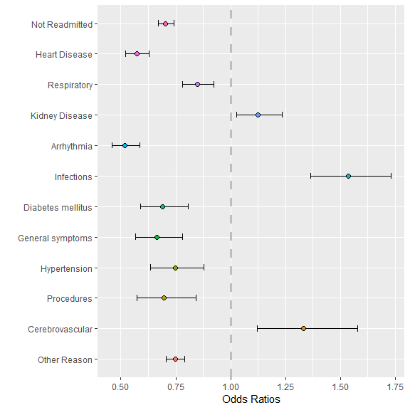

```r
out$names <- factor(out$names,
                    levels = rev(levels(case2$group)[-1]))
p7 <- ggplot(out,
              aes(x = names,
                  y = coef)) +
  coord_flip() +
  geom_hline(yintercept = 1,
             colour = "grey",
             size = 1.1,
             linetype = 2) +
  geom_errorbar(aes(ymin = lb,
                    ymax = ub),
                size = 0.4,
                width = 0.2) +
  geom_point(aes(x = names,
                 y = coef,
                 fill = names),
             size = 2,
             shape = 21) +
  scale_x_discrete("") +
  scale_y_continuous("Odds Ratios") +
  theme(legend.position = "none")

# Save for publication
tiff(filename = "tmp/fig4.tiff",
     height = 6,
     width = 6,
     units = "in",
     res = 600,
     compression = "lzw+p")
print(p7)
graphics.off()

p7
```

Compare to risk of 1-year (from the index HF discharge) all-cause mortality after the first HF readmission, not being readmitted or being readmitted for the first time for heart disease, respiratory problems, arrhythmia, diabetes, general symptoms, hypertension, procedures or other reasons decreased the risk. on the other hand, readmission for kidney disease, infections or cerebrovascular issues increased the risk.

# Appendix

## ICD Codes

### Diagnoses (ICD-9)

| Comorbidity | Variable | ICD9 |
| --- | --- | --- |
| AFib/AFlutter | af | 427.31; 427.32 |
| AMI | ami | 410.00; 410.01; 410.02; 410.10; 410.11; 410.12; 410.20; 410.21; 410.22; 410.30; 410.31; 410.32; 410.40; 410.41; 410.42; 410.50; 410.51; 410.52; 410.60; 410.61; 410.62; 410.70; 410.71; 410.72; 410.80; … |
| Anemia | anemia | 280.0; 280.1; 280.8; 280.9; 281.0; 281.1; 281.2; 281.3; 281.4; 281.8; 281.9; 285.21; 285.29; 285.8; 285.9 |
| CKD | ckd | 585.1; 585.2; 585.3; 585.4; 585.5; 585.6; 585.9 |
| COPD | copd | 490; 491.0; 491.1; 491.20; 491.21; 491.22; 491.8; 491.9; 492.0; 492.8; 493.00; 493.01; 493.02; 493.10; 493.11; 493.12; 493.20; 493.21; 493.22; 493.81; 493.82; 493.90; 493.91; 493.92; 494.0; 494.1; 495… |
| Cancer | cancer | 140.3; 140.4; 140.0; 140.1; 140.9; 140.8; 140.5; 140.6; 141.9; 141.3; 141.0; 141.2; 141.8; 141.4; 141.5; 141.6; 141.1; 142.1; 142.2; 142.8; 142.9; 142.0; 143.0; 143.9; 143.8; 143.1; 144.9; 144.0; 144.… |
| Diabetes | diab | 250.00; 250.01; 250.02; 250.03; 250.10; 250.11; 250.12; 250.13; 250.20; 250.21; 250.22; 250.23; 250.30; 250.31; 250.32; 250.33; 250.40; 250.41; 250.42; 250.43; 250.50; 250.51; 250.52; 250.53; 250.60; … |
| HF | hf | 428.0; 428.1; 428.20; 428.21; 428.22; 428.23; 428.30; 428.31; 428.32; 428.33; 428.40; 428.41; 428.42; 428.43; 428.9 |
| HIV | hiv | 042 |
| Hyperlipidemia | lipid | 272.0; 272.1; 272.2; 272.3; 272.4; 272.5; 272.6; 272.7; 272.8; 272.9 |

[output cut: 5 more lines]

### Cause of CV death (ICD-10)

| Diagnosis | ICD-10 |
| --- | --- |
| Major cardiovascular diseases | I00-I78 |
| Diseases of heart | I00-I09, I11, I13, I20-I51 |
| Hypertensive heart disease with or without renal disease | I11,I13 |
| Ischemic heart diseases | I20-I25 |
| Other diseases of heart | I00-I09,I26-I51 |
| Essential (primary) hypertension and hypertensive renal disease | I10,I12 |
| Cerebrovascular diseases | I60-I69 |
| Atherosclerosis | I70 |
| Other diseases of circulatory system | I71-I78 |

## Abbreviations

```r
# abbv <- data.table(Abbreviation = c("AMI",
#                                     "HF"),
#                    Description = c("Acute myocardial infarction",
#                                    "Heart failure"))
# setkey(abbv,
#        Abbreviation)
# DT::datatable(abbv,
#               caption = "Appendix Table 3: abbreviations",
#               class = "cell-border stripe",
#               options = list(searching = TRUE,
#                              pageLength = nrow(t1)))
```